# PROJECT WORK 1

#### 1. Problem Description

The dataset named Star is obtained from the website http://vincentarelbundock.github.io/Rdatasets/datasets.html. The dataset is a collection of 5748 observations of individual performance in math and reading tests accross 79 different schools. The variables are class sizes, years of teaching experience, gender, qualified for free lunch and race. Below are 5 example instances of the original dataset:

[figure not shown]

For the scope of this project work, we focus on choosing only one variable and regress math scores based on that variable. The variable chosen here is years of teaching experience. Comparing the original distribution of math scores vs. log-scale of math scores, log-scale math scores seems to follow normal distribution better. Therefore, we choose to build our models with log-scale math scores.

Data distribution:

[figure not shown]

#### 2. Model description

In the sections following, we will go through 4 different models:

- Pooled model: all school belongs to the same distribution, log math scores is regressed based on years of teaching experience. Parameters are beta1, beta2 and sigma that are common for all schools.

  ```
                                    y ~ N(beta1 + beta2*x, sigma)
  ```

- Separate model: each school has its own separate model. The parameters are alpha (unique for each school), beta and sigma (common for all schools)

  ```
                                    mu = alpha_school + beta*x
                                    y ~ N(mu, sigma)
  ```

- Varying slop and intercept model: each school has its own separate model with both alpha and beta unique for each school, sigma is common for all schools. Alpha and beta follows normal distribution with priors:

  ```
                                    mu_alpha ~ N(0,1)
                                    mu_beta ~ N(0,1)
                                    alpha ~ N(mu_alpha, sigma_alpha)
                                    alpha ~ N(mu_alpha, sigma_alpha)
                                    mu = alpha_school + beta_school*x
                                    y ~ N(mu, sigma)
  ```

- Hierarchical model with no regressor: each school has its own parameters mu that follows a normal distribution (mu0, sigma0) and shared sigma.

  ```
                                    mu ~ (mu0, sigma0)
                                    y ~ (mu, sigma)
  ```

For evaluation purpose, we split up training-test data with 2133 data points used for training and the rest is for evaluating the accuracy of each models.

The codes are passed to PyStan and simulated with 2 chains in 1000 iterations.

#### 2.1. Pooled model

Stan code:

```
data {
    int<lower=0>  N; //Number of train data
    int<lower=0> M; //Number of test data
    vector[N] x; // Variable - teaching experience
    vector[M] x_test; // Test variable
    vector[N] y; // Labels - log math score
}
parameters {
    vector[2] beta;
    real<lower=0> sigma; //sigma is constrained to be positive
}
model {
    y ~ normal(beta[1] + beta[2]*x, sigma);
}
generated quantities{
    vector[N] log_lik;
    vector[M] y_pred_test;
    for (i in 1:M)
     y_pred_test[i] = normal_rng(beta[1] + beta[2]*x_test[i], sigma);
    for (i in 1:N)
     log_lik[i] = normal_lpdf(y[i]| beta[1] + beta[2]*x[i], sigma);
}
```

#### 2.2. Separate model

Stan code

```
data{
    int<lower=0> N;
    int<lower=1, upper=79> school[N]; #school indicator
    vector[N] x;
    vector[N] y;
}
parameters {
    vector[79] alpha;
    real beta;
    real<lower=0> sigma;
}
transformed parameters {
    vector[N] mu;
    for (i in 1:N)
        mu[i] <- beta* x[i] + alpha[school[i]];
}
model {
    y ~ normal(mu, sigma);
}
generated quantities{
    vector[N] log_lik;
    for (i in 1:N)
     log_lik[i] = normal_lpdf(y[i]| mu[i], sigma);
}
```

#### 2.3. Varying intercept and slope model

Stan code:

```
`data {
  int<lower=0> N;
  int<lower=0> J;
  vector[N] y;
  vector[N] x;
  int school[N];
}
parameters {
  real<lower=0> sigma;
  real<lower=0> sigma_a;
  real<lower=0> sigma_b;
  vector[J] alpha;
  vector[J] beta;
  real mu_a;
  real mu_b;
}
transformed parameters {
    vector[N] mu;
    for (i in 1:N)
        mu[i] <- alpha[school[i]] + beta[school[i]]*x[i];
}
model {
  mu_a ~ normal(0, 1);
  mu_b ~ normal(0, 1);

  alpha ~ normal(mu_a, sigma_a);
  beta ~ normal(mu_b, sigma_b);
  y ~ normal(mu, sigma);
}

generated quantities{
    vector[N] log_lik;
    for (i in 1:N)
     log_lik[i] = normal_lpdf(y[i]| mu[i], sigma);
}`
```

#### 2.4. Hierarchical model

Stan code:

```
data {
    int<lower=1> N;
    int<lower=1> K;
    int<lower=1, upper = K> x[N];
    vector[N] y;
}
parameters {
    real mu0;
    real<lower=0> sigma0;
    vector[K] mu;
    real<lower=0> sigma;
}
model {
    mu ~ normal(mu0, sigma0);
    y~ normal(mu[x], sigma);

}
generated quantities {
    real mupred;
    real ypred;
    vector[N] log_lik;
    mupred = normal_rng(mu0, sigma0);
    ypred = normal_rng(mupred, sigma);
    for (i in 1:N)
        log_lik[i] = normal_lpdf(y[i] | mu[x[i]], sigma);
}
```

#### 3. Convergence and Result

#### 3.1. Pooled model

R-hat for all variables is approximately 1.0, so we can conclude that the model has converged. Checking effective sample size and divergence returns value True, meaning that there is no problem with the model. The graph below demonstrates the fitted line.

[figure not shown]

#### 3.2. Separate model

R-hat for all variables is approximately 1.0, so we can conclude that the model has converged. Checking effective sample size and divergence returns value True, meaning that there is no problem with the model. Alpha (intercept) calculated for different schools:

[figure not shown]

#### 3.3. Varying intercept and slope model

R-hat for all variables is approximately 1.0, so we can conclude that the model has converged. Checking effective sample size returns True. However, divergence check returns False. The model may be bias and thus we choose not to continue with this model. Alpha (intercept) calculated for different schools:

[figure not shown]

Beta (slope) calculated for different schools:

[figure not shown]

#### 3.4. Hierarchical model

R-hat for all variables is approximately 1.0, so we can conclude that the model has converged. Checking effective sample size and divergence returns value True, meaning that there is no problem with the model

#### 4. Model evaluation with Psis-loo

Two methods for model evaluation has been used in this project: psis-loo and MAE.

Psisloo results for each model:

[output not shown]

Scatter plot of ks values for different models:

- Pooled model: all k values is below 0.5. We can conclude that the parameter estimations of the model is reliable

[figure not shown]

- Separate model: all k values is below 0.5. We can conclude that the parameter estimations of the model is reliable.

[figure not shown]

[figure not shown]

#### 5. Posterior predictive checking

MAE and MSE results for each model:

[output not shown]

Posterior distribution:

- Pooled model

[figure not shown]

- Separate model

[figure not shown]

- Hierarchical model

[figure not shown]

#### 6. Conclusion and potential improvements

Within the scope of this project, we only explore one variable effect on math score results. Further analysis can be done with additional variables to improve prediction accuracy.

#### 7. References

Codes adapted from Fonnesbeck, C. A Primer on Bayesian Multilevel Modeling using PyStan. URL: http://mc-stan.org/users/documentation/case-studies/radon.html?fbclid=IwAR3h_03XtQnyJQ18EOdREkPX-4biDX7c5AN5e9DPQzQLZ6hB2JRFh1gHemQ

Dataset collected from Rdatasets. URL: http://vincentarelbundock.github.io/Rdatasets/datasets.html

# PROJECT WORK 2

#### 1. Problem Description

The dataset named Score is obtained from the website https://www.kaggle.com/nycopendata/high-schools. The dataset is a collection of 435 observations of the average score in SAT math, reading and writing tests from all high schools of 5 different boroughs in New York City. Below are the variables of the original dataset:

[figure not shown]

For the scope of this project work, we focus on choosing only one variable and regress SAT average math scores based on that variable. The variable chosen here is the student enrollment. Comparing the original distribution of math scores vs. log-scale of math scores, log-scale math scores seems to follow normal distribution better. Therefore, we choose to build our models with log-scale math scores.

Data distribution:

[figure not shown]

#### 2. Model description

In the sections following, we will go through 4 different models:

- Pooled model: all borough belongs to the same distribution, log math scores is regressed based on the number of student enrollment. Parameters are beta1, beta2 and sigma that are common for all boroughs.

  ```
                                    y ~ N(beta1 + beta2*x, sigma)
  ```

- Separate model: each borough has its own separate model. The parameters are alpha (unique for each borough), beta and sigma (common for all boroughs)

  ```
                                    mu = alpha_borough + beta*x
                                    y ~ N(mu, sigma)
  ```

- Varying slop and intercept model: each borough has its own separate model with both alpha and beta unique for each borough, sigma is common for all boroughs. Alpha and beta follows normal distribution with priors:

  ```
                                    mu_alpha ~ N(0,1)
                                    mu_beta ~ N(0,1)
                                    alpha ~ N(mu_alpha, sigma_alpha)
                                    alpha ~ N(mu_alpha, sigma_alpha)
                                    mu = alpha_borough + beta_borough*x
                                    y ~ N(mu, sigma)
  ```

#### 2.1. Pooled model

Stan code:

```
data {
    int<lower=0>  N;
    int<lower=0> M;
    vector[N] x;
    vector[M] x_test;
    vector[N] y;
}
parameters {
    vector[2] beta;
    real<lower=0> sigma;
}
model {
    y ~ normal(beta[1] + beta[2]*x, sigma);
}
generated quantities{
    vector[N] log_lik;
    vector[M] y_pred_test;
    for (i in 1:M)
     y_pred_test[i] = normal_rng(beta[1] + beta[2]*x_test[i], sigma);
    for (i in 1:N)
     log_lik[i] = normal_lpdf(y[i]| beta[1] + beta[2]*x[i], sigma);
}
```

#### 2.2. Separate model

Stan code

```
data{
    int<lower=0> N;
    int<lower=1, upper=5> boroughs[N]; #borough indicator
    vector[N] x;
    vector[N] y;
}
parameters {
    vector[4] alpha;
    real beta; #only 1 beta, not a vector
    real<lower=0> sigma;
}
transformed parameters {
    vector[N] mu;
    for (i in 1:N)
        mu[i] <- beta* x[i] + alpha[boroughs[i]];
}
model {
    y ~ normal(mu, sigma);
}
generated quantities{
    vector[N] log_lik;
    for (i in 1:N)
     log_lik[i] = normal_lpdf(y[i]| mu[i], sigma);
}
```

#### 2.3. Varying intercept and slope model

Stan code:

```
data {
  int<lower=0> N;
  int<lower=0> J;
  vector[N] y;
  vector[N] x;
  int boroughs[N];
}
parameters {
  real<lower=0> sigma;
  real<lower=0> sigma_a;
  real<lower=0> sigma_b;
  vector[J] alpha;
  vector[J] beta;
  real mu_a;
  real mu_b;
}
transformed parameters {
    vector[N] mu;
    for (i in 1:N)
        mu[i] <- alpha[boroughs[i]] + beta[boroughs[i]]*x[i];
}
model {
  mu_a ~ normal(0, 1);
  mu_b ~ normal(0, 1);
  alpha ~ normal(mu_a, sigma_a);
  beta ~ normal(mu_b, sigma_b);
  y ~ normal(mu, sigma);
}
generated quantities{
    vector[N] log_lik;
    for (i in 1:N)
     log_lik[i] = normal_lpdf(y[i]| mu[i], sigma);
}
```

#### 2.4. Hierarchical model

Stan code:

```
data {
    int<lower=1> N;
    int<lower=1> K;
    matrix[N, K] y;
}
parameters {
    real mu0;
    real<lower=0> sigma0;
    vector[K] mu;
    real<lower=0> sigma;
}
model {
    for (j in 1:K){
        mu[j] ~ normal(mu0, sigma0);
        y[:,j] ~ normal(mu[j], sigma);
     }
}
generated quantities {
    real mupred;
    mupred <- normal_rng(mu0, sigma0);
}
```

#### 3. Convergence and Result

#### 3.1. Pooled model

[figure not shown]

#### 3.2. Separate model

[figure not shown]

#### 3.3. Varying intercept and slope model

[figure not shown]

Beta (slope) calculated for different boroughs:

[figure not shown]

#### 4. Model evaluation with Psis-loo

Two methods for model evaluation has been used in this project: psis-loo and MAE.

Psisloo results for each model:

[output not shown]

Scatter plot of ks values for different models:

- Pooled model: all k values is below 0.5. We can conclude that the parameter estimations of the model is reliable.

[figure not shown]

- Separate model: all k values is below 0.5. We can conclude that the parameter estimations of the model is reliable.

[figure not shown]

- Vary slope and intercept model: some k values is higher than 0.5. The estimates might be biased.

[figure not shown]

#### 5. Posterior predictive checking

MAE and MSE results for each model:

[output not shown]

#### 6. Conclusion and potential improvements

Within the scope of this project, we only explore one variable effect on math score results. Further analysis can be done with additional variables to improve prediction accuracy.

#### 7. References

Codes adapted from Fonnesbeck, C. A Primer on Bayesian Multilevel Modeling using PyStan. URL: http://mc-stan.org/users/documentation/case-studies/radon.html?fbclid=IwAR3h_03XtQnyJQ18EOdREkPX-4biDX7c5AN5e9DPQzQLZ6hB2JRFh1gHemQ

Dataset collected from Rdatasets. URL: https://www.kaggle.com/nycopendata/high-schools

```python
%matplotlib inline
import numpy as np
import pandas as pd
import matplotlib.pyplot as plt
import seaborn as sns; sns.set_context('notebook')
import stanity
import pystan
```

```python
from sklearn.metrics import mean_absolute_error as MAE
from sklearn.metrics import mean_squared_error as MSE
```

```python
np.random.seed(10)
import warnings
warnings.filterwarnings('ignore')
```

```python
star = pd.read_csv('Star.csv', index_col=0, header = 0)
```

```python
star.head()
```

|  | tmathssk | treadssk | classk | totexpk | sex | freelunk | race | schidkn |
| --- | --- | --- | --- | --- | --- | --- | --- | --- |
| 2 | 473 | 447 | small.class | 7 | girl | no | white | 63 |
| 3 | 536 | 450 | small.class | 21 | girl | no | black | 20 |
| 5 | 463 | 439 | regular.with.aide | 0 | boy | yes | black | 19 |
| 11 | 559 | 448 | regular | 16 | boy | no | white | 69 |
| 12 | 489 | 447 | small.class | 5 | boy | yes | white | 79 |

```python
len(np.unique(star.schidkn))
```

```
79
```

```python
schools = star.schidkn.unique()
```

```python
np.sort(schools)
```

```
array([ 1,  2,  3,  4,  5,  6,  7,  8,  9, 10, 11, 12, 13, 14, 15, 16, 17,
       18, 19, 20, 21, 22, 23, 24, 25, 26, 27, 28, 29, 30, 31, 32, 33, 34,
       35, 36, 37, 38, 39, 40, 41, 42, 43, 44, 45, 46, 47, 48, 49, 50, 51,
       52, 53, 54, 55, 56, 57, 58, 59, 60, 61, 62, 63, 64, 65, 66, 67, 68,
       69, 70, 71, 72, 73, 74, 75, 76, 78, 79, 80])
```

```python
star.loc[star.schidkn>=78,'schidkn'] -= 1
```

```python
schools = star.schidkn.unique()
```

```python
df = pd.DataFrame()
```

```python
for col in ['tmathssk', 'treadssk', 'totexpk', 'schidkn' ]:
    data = star.loc[:,col]
    df[col] = data
data = star.loc[:,['classk', 'sex', 'freelunk','race']]
df = df.merge(pd.get_dummies(data), left_index=True, right_index=True)
```

```python
print(df.columns[[4, 6, 8]])
print(df.head())
```

```
Index(['classk_regular', 'classk_small.class', 'sex_girl'], dtype='object')
    tmathssk  treadssk  totexpk  schidkn  classk_regular  \
2        473       447        7       63               0
3        536       450       21       20               0
5        463       439        0       19               0
11       559       448       16       69               1
12       489       447        5       78               0

    classk_regular.with.aide  classk_small.class  sex_boy  sex_girl  \
2                          0                   1        0         1
3                          0                   1        0         1
5                          1                   0        1         0
11                         0                   0        1         0
12                         0                   1        1         0

    freelunk_no  freelunk_yes  race_black  race_other  race_white
2             1             0           0           0           1
3             1             0           1           0           0
5             0             1           1           0           0
11            1             0           0           0           1
12            0             1           0           0           1
```

```python
df.drop(df.columns[[5, 7, 9, 12]], axis=1, inplace=True)
```

```python
df.columns = ['math', 'reading', 'year_teaching', 'school','reg_class', 'sml_class', 'is_girl', 'free_lunch', 'black','white']
```

```python
df.head()
```

|  | math | reading | year_teaching | school | reg_class | sml_class | is_girl | free_lunch | black | white |
| --- | --- | --- | --- | --- | --- | --- | --- | --- | --- | --- |
| 2 | 473 | 447 | 7 | 63 | 0 | 1 | 1 | 0 | 0 | 1 |
| 3 | 536 | 450 | 21 | 20 | 0 | 1 | 1 | 0 | 1 | 0 |
| 5 | 463 | 439 | 0 | 19 | 0 | 0 | 0 | 1 | 1 | 0 |
| 11 | 559 | 448 | 16 | 69 | 1 | 0 | 0 | 0 | 0 | 1 |
| 12 | 489 | 447 | 5 | 78 | 0 | 1 | 0 | 1 | 0 | 1 |

```python
df.corr()['math'].sort_values()
```

```
free_lunch      -0.243111
black           -0.174493
reg_class       -0.036504
school           0.045439
sml_class        0.080078
is_girl          0.081041
year_teaching    0.096687
white            0.174968
reading          0.713549
math             1.000000
Name: math, dtype: float64
```

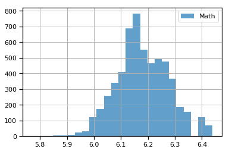

```python
df.math.apply(lambda x:np.log(x)).hist(bins=25, alpha = 0.7, label = "Math")
plt.legend()
plt.show()
```

### Train/Test Split

```python
X = df.drop('math', axis=1)
Y = np.log(df.math)
```

```python
indices = range(df.shape[0])
i_schools = []
len_ischools = []
```

```python
for s in schools:
    i_school = np.where(df.school == s)[0]
    len_ischools.append(len(i_school))
    i_schools.append(i_school)
```

```python
min_len = min(len_ischools)
train_size = round(min_len*0.8)
```

```python
train_idx = []
test_idx = []
```

```python
for s in i_schools:
    np.random.shuffle(s)
    train_idx = np.concatenate((train_idx, s[:train_size]), axis=None)
    test_idx = np.concatenate((test_idx, s[train_size:]), axis=None)
```

```python
len(train_idx)
```

```
2133
```

```python
len(test_idx)
```

```
3615
```

```python
X_train = X.iloc[train_idx,:]
X_test = X.iloc[test_idx,:].reset_index()
Y_train = Y.iloc[train_idx]
Y_test = Y.iloc[test_idx]
```

# TRAIN TEST SPLIT II

```python
#from sklearn.model_selection import train_test_split
#X = df.drop('math', axis=1)
#Y = np.log(df.math)
#X_train, X_test, Y_train, Y_test = train_test_split(X, Y, stratify= X.school, test_size=0.2, random_state=42)
```

```python
#len(X_train)
```

## Pooled model

```python
pooled_code = """
data {
    int<lower=0>  N;
    int<lower=0> M;
    vector[N] x;
    vector[M] x_test;
    vector[N] y;
}
parameters {
    vector[2] beta;
    real<lower=0> sigma;
}
model {
    y ~ normal(beta[1] + beta[2]*x, sigma);
}
generated quantities{
    vector[N] log_lik;
    vector[M] y_pred_test;
    for (i in 1:M)
     y_pred_test[i] = normal_rng(beta[1] + beta[2]*x_test[i], sigma);
    for (i in 1:N)
     log_lik[i] = normal_lpdf(y[i]| beta[1] + beta[2]*x[i], sigma);
}

"""
```

```python
pool_data = {
    'N': Y_train.shape[0],
    'M': Y_test.shape[0],
    'x': X_train.loc[:,'year_teaching'],
    'x_test': X_test.loc[:,'year_teaching'],
    'y': Y_train,
}
```

```python
pooled_fit = pystan.stan(model_code=pooled_code, data = pool_data, iter = 1000, chains = 2)
```

```
INFO:pystan:COMPILING THE C++ CODE FOR MODEL anon_model_174aac4ec68a4e0adc2676445f7b9556 NOW.
```

```python
print("Rhat check : ",pystan.diagnostics.check_rhat(pooled_fit))
print("N_eff check : ",pystan.diagnostics.check_n_eff(pooled_fit))
print("Divergence check: ", pystan.diagnostics.check_div(pooled_fit))
```

```
Rhat check :  True
N_eff check :  True
Divergence check:  True
```

```
psisloo:  2006.8115161508165
p_eff:  2.8659596998579673
```

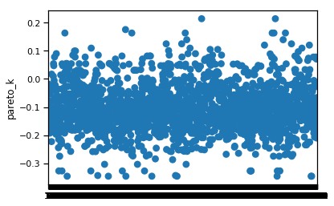

```python
pooled_sample = pooled_fit.extract(permuted=True)

loglik = (pooled_sample["log_lik"])
psisloo = stanity.psisloo(loglik)
print("psisloo: ",psisloo.elpd)
psisloo.plot()
lppd_pooled = 0
for i in range (Y_train.shape[0]):
    lppd_pooled = lppd_pooled + np.log(np.mean(np.exp(loglik[:,i])))

peff_pooled = np.sum(lppd_pooled) - psisloo.elpd
print("p_eff: ", peff_pooled)
```

```python
psisloo.print_summary()
```

```
greater than 0.5    0.0
greater than 1      0.0
dtype: float64
```

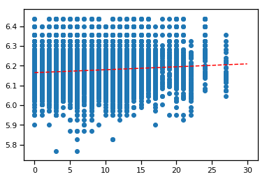

```python
b0, m0 = pooled_sample['beta'].T.mean(1)
plt.scatter(df.year_teaching, np.log(df.math))
xvals = np.linspace(0,30)
plt.plot(xvals, m0*xvals+b0, 'r--')
plt.show()
```

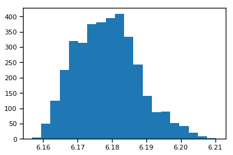

```python
#Comparing y_pred with y_test
y_pred = np.mean(pooled_sample["y_pred_test"], axis=0)
plt.hist(y_pred, bins = 20)
```

```python
round(MSE(Y_test, y_pred),3)
```

```
0.01
```

```python
round(MAE(Y_test, y_pred),3)
```

```
0.078
```

## Separate model

```python
separate_code = """
data{
    int<lower=0> N;
    int<lower=1, upper=79> school[N]; #school indicator
    vector[N] x;
    vector[N] y;
}
parameters {
    vector[79] alpha;
    real beta; #only 1 beta, not a vector
    real<lower=0> sigma;
}
transformed parameters {
    vector[N] mu;
    for (i in 1:N)
        mu[i] <- beta* x[i] + alpha[school[i]];
}
model {
    y ~ normal(mu, sigma);
}
generated quantities{
    vector[N] log_lik;
    for (i in 1:N)
     log_lik[i] = normal_lpdf(y[i]| mu[i], sigma);
}
"""
```

```python
separate_data = {'N': X_train.shape[0],
                 'school': X_train.school,
                 'x': X_train.loc[:,'year_teaching'],
                 'y': Y_train }
```

```python
separate_fit = pystan.stan(model_code = separate_code, data = separate_data, iter = 1000, chains = 2)
separate_sample = separate_fit.extract(permuted=True)
```

```
INFO:pystan:COMPILING THE C++ CODE FOR MODEL anon_model_3f346b560546d258f094491925426d10 NOW.
```

```python
print("Rhat check : ",pystan.diagnostics.check_rhat(separate_fit))
print("N_eff check : ",pystan.diagnostics.check_n_eff(separate_fit))
print("Divergence check: ", pystan.diagnostics.check_div(separate_fit))
```

```
Rhat check :  True
N_eff check :  True
Divergence check:  True
```

```python
alpha = np.mean(separate_fit['alpha'], axis=0)
beta = np.mean(separate_fit['beta'])
```

```
psisloo:  2210.08627718663
p_eff:  79.23106462039004
```

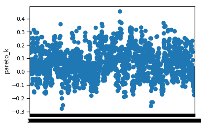

```python
loglik = (separate_sample["log_lik"])
psisloo = stanity.psisloo(loglik)
print("psisloo: ",psisloo.elpd)
psisloo.plot()
lppd_pooled = 0
for i in range (Y_train.shape[0]):
    lppd_pooled = lppd_pooled + np.log(np.mean(np.exp(loglik[:,i])))

peff_pooled = np.sum(lppd_pooled) - psisloo.elpd
print("p_eff: ", peff_pooled)
```

```python
psisloo.print_summary()
```

```
greater than 0.5    0.0
greater than 1      0.0
dtype: float64
```

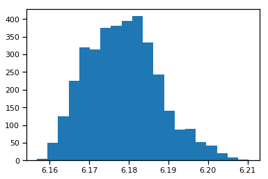

```python
Y_pred = []
for i in range(X_test.shape[0]):
    school = X_test.loc[i, 'school']
    Y_pred.append(alpha[school-1] + beta*X_test.loc[i, 'year_teaching'])

plt.hist(y_pred, bins = 20)
```

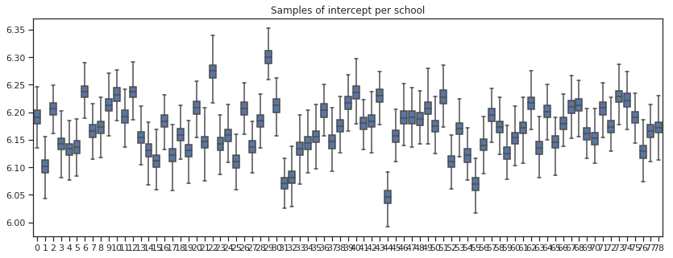

```python
import seaborn as sns
sns.set(style="ticks")

a_sample = pd.DataFrame(separate_fit['alpha'])
plt.figure(figsize=(14, 5))
sns.boxplot(data=a_sample, whis=np.inf, color="b")
plt.title("Samples of intercept per school")
plt.show()
```

# Varying intercept and slope model

```python
varying_intercept_slope = """
data {
  int<lower=0> N;
  int<lower=0> J;
  vector[N] y;
  vector[N] x;
  int school[N];
}
parameters {
  real<lower=0> sigma;
  real<lower=0> sigma_a;
  real<lower=0> sigma_b;
  vector[J] alpha;
  vector[J] beta;
  real mu_a;
  real mu_b;
}
transformed parameters {
    vector[N] mu;
    for (i in 1:N)
        mu[i] <- alpha[school[i]] + beta[school[i]]*x[i];
}
model {
  mu_a ~ normal(0, 1);
  mu_b ~ normal(0, 1);

  alpha ~ normal(mu_a, sigma_a);
  beta ~ normal(mu_b, sigma_b);
  y ~ normal(mu, sigma);
}

generated quantities{
    vector[N] log_lik;
    for (i in 1:N)
     log_lik[i] = normal_lpdf(y[i]| mu[i], sigma);
}

"""
```

```python
varying_intercept_slope_data = {'N': X_train.shape[0],
                          'J': 79,
                          'school': X_train.school,
                          'x': X_train.loc[:,'year_teaching'],
                          'y': Y_train}

varying_intercept_slope_fit = pystan.stan(model_code=varying_intercept_slope,
                                          data=varying_intercept_slope_data,
                                          iter=1000, chains=2)
varying_intercept_slope_sample = varying_intercept_slope_fit.extract(permuted=True)
```

```
INFO:pystan:COMPILING THE C++ CODE FOR MODEL anon_model_fc996b18191bb3d6f59ec43aa9146fea NOW.
WARNING:pystan:1 of 1000 iterations ended with a divergence (0.1%).
WARNING:pystan:Try running with adapt_delta larger than 0.8 to remove the divergences.
```

```python
print("Rhat check : ",pystan.diagnostics.check_rhat(varying_intercept_slope_fit))
print("N_eff check : ",pystan.diagnostics.check_n_eff(varying_intercept_slope_fit))
print("Divergence check: ", pystan.diagnostics.check_div(varying_intercept_slope_fit))
```

```
Rhat check :  True
```

```
WARNING:pystan:1 of 1000 iterations ended with a divergence (0.1%).
WARNING:pystan:Try running with adapt_delta larger than 0.8 to remove the divergences.
```

```
N_eff check :  True
Divergence check:  False
```

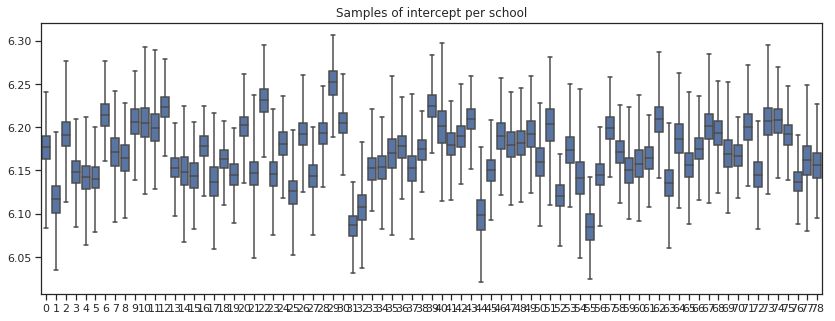

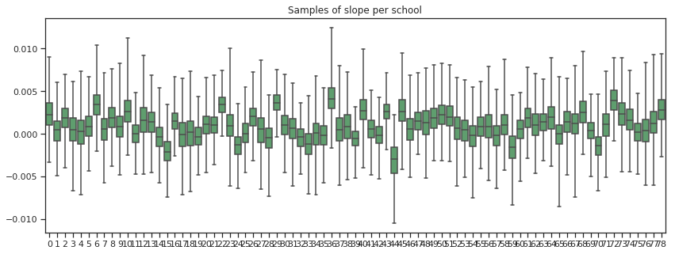

```python
sns.set(style="ticks")

a_sample = pd.DataFrame(varying_intercept_slope_sample['alpha'])
plt.figure(figsize=(14, 5))
sns.boxplot(data=a_sample, whis=np.inf, color="b")
plt.title("Samples of intercept per school")
plt.show()

b_sample = pd.DataFrame(varying_intercept_slope_sample['beta'])
plt.figure(figsize=(14, 5))
sns.boxplot(data=b_sample, whis=np.inf, color = 'g')
plt.title("Samples of slope per school")
plt.show()
```

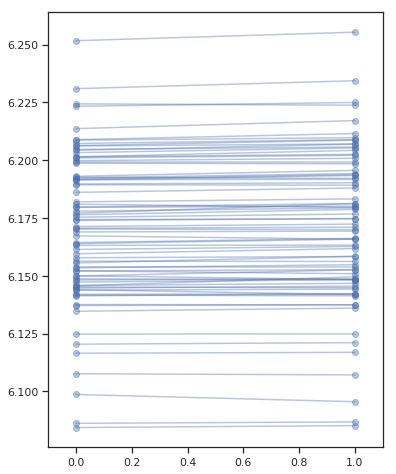

```python
xvals = np.arange(2)
b = varying_intercept_slope_fit['alpha'].mean(axis=0)
m = varying_intercept_slope_fit['beta'].mean(axis=0)
plt.figure(figsize=(6,8))
for bi,mi in zip(b,m):
    plt.plot(xvals, mi*xvals + bi, 'bo-', alpha=0.4)
plt.xlim(-0.1, 1.1);
```

```
psisloo:  2226.7430736213073
p_eff:  87.34224120591534
```

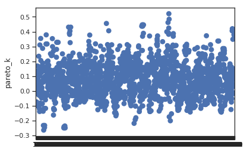

```python
loglik = (varying_intercept_slope_sample["log_lik"])
psisloo = stanity.psisloo(loglik)
print("psisloo: ",psisloo.elpd)
psisloo.plot()
lppd_pooled = 0
for i in range (Y_train.shape[0]):
    lppd_pooled = lppd_pooled + np.log(np.mean(np.exp(loglik[:,i])))

peff_pooled = np.sum(lppd_pooled) - psisloo.elpd
print("p_eff: ", peff_pooled)
```

```python
psisloo.print_summary()
```

```
greater than 0.5    0.000469
greater than 1      0.000000
dtype: float64
```

## Hierarchical model with no regression variable

First, let's look at the code.

```python
hierarchical_code = """
data {
    int<lower=1> N;
    int<lower=1> K;
    int<lower=1, upper = K> x[N];
    vector[N] y;
}
parameters {
    real mu0;
    real<lower=0> sigma0;
    vector[K] mu;
    real<lower=0> sigma;
}
model {
    mu ~ normal(mu0, sigma0);
    y~ normal(mu[x], sigma);

}
generated quantities {
    real mupred;
    vector[N] log_lik;
    mupred = normal_rng(mu0, sigma0);
    for (i in 1:N)
        log_lik[i] = normal_lpdf(y[i] | mu[x[i]], sigma);
}
"""
```

```python
data_hierarchical = {'N': X_train.shape[0],
                    'K': 79,
                    'x': X_train.school,
                    'y': Y_train}

fit_hierarchical = pystan.stan(model_code=hierarchical_code,
                                          data=data_hierarchical,
                                          iter=1000, chains=2)
hierarchical_sample = fit_hierarchical.extract(permuted=True)
```

```
INFO:pystan:COMPILING THE C++ CODE FOR MODEL anon_model_59b14ee0cfb87f982e0d1d0a692c46bd NOW.
```

```python
print("Rhat check : ",pystan.diagnostics.check_rhat(fit_hierarchical))
print("N_eff check : ",pystan.diagnostics.check_n_eff(fit_hierarchical))
print("Divergence check: ", pystan.diagnostics.check_div(fit_hierarchical))
```

```
Rhat check :  True
N_eff check :  True
Divergence check:  True
```

```
psisloo:  2212.854263695853
p_eff:  69.57584553283459
```

```
greater than 0.5    0.0
greater than 1      0.0
dtype: float64
```

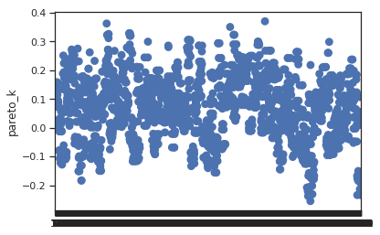

```python
loglik = (fit_hierarchical["log_lik"])
psisloo = stanity.psisloo(loglik)
print("psisloo: ",psisloo.elpd)
psisloo.plot()
lppd_pooled = 0
for i in range (Y_train.shape[0]):
    lppd_pooled = lppd_pooled + np.log(np.mean(np.exp(loglik[:,i])))

peff_pooled = np.sum(lppd_pooled) - psisloo.elpd
print("p_eff: ", peff_pooled)
psisloo.print_summary()
```

```python
mu_pred = np.mean(fit_hierarchical['mupred'])
sigma_pred = np.mean(fit_hierarchical['sigma'])
mu_ytest = np.mean(Y_test)
sigma_ytest = np.std(Y_test)
y_norm = (Y_test - mu_ytest)/sigma_ytest
y_pred = (y_norm * sigma_pred) + mu_pred
```

```python
round(MAE(Y_test, y_pred),3)
```

```
0.011
```

```python
round(MSE(Y_test, y_pred),3)
```

```
0.0
```

```python
%matplotlib inline
import numpy as np
import pandas as pd
import matplotlib.pyplot as plt
import seaborn as sns; sns.set_context('notebook')
import stanity
```

```python
from sklearn.metrics import mean_absolute_error as MAE
from sklearn.metrics import mean_squared_error as MSE
```

```python
np.random.seed(100)
```

```python
score = pd.read_csv('NYC Public Schools/scores.csv', index_col=0, header = 0)
score.head()
```

| School ID | School Name | Borough | Building Code | Street Address | City | State | Zip Code | Latitude | Longitude | Phone Number | ... | End Time | Student Enrollment | Percent White | Percent Black | Percent Hispanic | Percent Asian | Average Score (SAT Math) | Average Score (SAT Reading) | Average Score (SAT Writing) | Percent Tested |
| --- | --- | --- | --- | --- | --- | --- | --- | --- | --- | --- | --- | --- | --- | --- | --- | --- | --- | --- | --- | --- | --- |
| 02M260 | Clinton School Writers and Artists | Manhattan | M933 | 425 West 33rd Street | Manhattan | NY | 10001 | 40.75321 | -73.99786 | 212-695-9114 | ... | NaN | NaN | NaN | NaN | NaN | NaN | NaN | NaN | NaN | NaN |
| 06M211 | Inwood Early College for Health and Informatio... | Manhattan | M052 | 650 Academy Street | Manhattan | NY | 10002 | 40.86605 | -73.92486 | 718-935-3660 | ... | 3:00 PM | 87.0 | 3.4% | 21.8% | 67.8% | 4.6% | NaN | NaN | NaN | NaN |
| 01M539 | New Explorations into Science, Technology and ... | Manhattan | M022 | 111 Columbia Street | Manhattan | NY | 10002 | 40.71873 | -73.97943 | 212-677-5190 | ... | 4:00 PM | 1735.0 | 28.6% | 13.3% | 18.0% | 38.5% | 657.0 | 601.0 | 601.0 | 91.0% |
| 02M294 | Essex Street Academy | Manhattan | M445 | 350 Grand Street | Manhattan | NY | 10002 | 40.71687 | -73.98953 | 212-475-4773 | ... | 2:45 PM | 358.0 | 11.7% | 38.5% | 41.3% | 5.9% | 395.0 | 411.0 | 387.0 | 78.9% |
| 02M308 | Lower Manhattan Arts Academy | Manhattan | M445 | 350 Grand Street | Manhattan | NY | 10002 | 40.71687 | -73.98953 | 212-505-0143 | ... | 3:00 PM | 383.0 | 3.1% | 28.2% | 56.9% | 8.6% | 418.0 | 428.0 | 415.0 | 65.1% |

5 rows × 21 columns

```python
score.info()
```

```
<class 'pandas.core.frame.DataFrame'>
Index: 435 entries, 02M260 to 27Q323
Data columns (total 21 columns):
School Name                    435 non-null object
Borough                        435 non-null object
Building Code                  435 non-null object
Street Address                 435 non-null object
City                           435 non-null object
State                          435 non-null object
Zip Code                       435 non-null int64
Latitude                       435 non-null float64
Longitude                      435 non-null float64
Phone Number                   435 non-null object
Start Time                     431 non-null object
End Time                       431 non-null object
Student Enrollment             428 non-null float64
Percent White                  428 non-null object
Percent Black                  428 non-null object
Percent Hispanic               428 non-null object
Percent Asian                  428 non-null object
Average Score (SAT Math)       375 non-null float64
Average Score (SAT Reading)    375 non-null float64
Average Score (SAT Writing)    375 non-null float64
Percent Tested                 386 non-null object
dtypes: float64(6), int64(1), object(14)
memory usage: 74.8+ KB
```

```python
df = score.loc[:,['School Name', 'Borough', 'Student Enrollment', 'Average Score (SAT Math)']]
df.columns = ['SchoolName', "Borough", "Enrollment", "math"]
df.head()
df.info()
```

```
<class 'pandas.core.frame.DataFrame'>
Index: 435 entries, 02M260 to 27Q323
Data columns (total 4 columns):
SchoolName    435 non-null object
Borough       435 non-null object
Enrollment    428 non-null float64
math          375 non-null float64
dtypes: float64(2), object(2)
memory usage: 17.0+ KB
```

```python
df.dropna(inplace=True)
print(df.Borough.value_counts())
```

```
Brooklyn         109
Bronx             98
Manhattan         89
Queens            69
Staten Island     10
Name: Borough, dtype: int64
```

```python
st_island = df.index[df.Borough == 'Staten Island']
```

```python
df.shape
```

```
(375, 4)
```

```python
test_df = df.loc[st_island, :]
```

```python
df.drop(st_island, inplace=True)
```

```python
df.info()
```

```
<class 'pandas.core.frame.DataFrame'>
Index: 365 entries, 01M539 to 27Q323
Data columns (total 4 columns):
SchoolName    365 non-null object
Borough       365 non-null object
Enrollment    365 non-null float64
math          365 non-null float64
dtypes: float64(2), object(2)
memory usage: 14.3+ KB
```

```python
df.Borough.unique()
```

```
array(['Manhattan', 'Bronx', 'Queens', 'Brooklyn'], dtype=object)
```

```python
replace_map = {'Borough':{'Manhattan': 1, 'Bronx': 2, 'Queens':3, 'Brooklyn':4}}
df.replace(replace_map, inplace = True)
print(df.head())
boroughs = df.Borough.unique()
print(boroughs)
```

```
                                                  SchoolName  Borough  \
School ID
01M539     New Explorations into Science, Technology and ...        1
02M294                                  Essex Street Academy        1
02M308                          Lower Manhattan Arts Academy        1
02M545       High School for Dual Language and Asian Studies        1
01M292         Henry Street School for International Studies        1

           Enrollment   math
School ID
01M539         1735.0  657.0
02M294          358.0  395.0
02M308          383.0  418.0
02M545          416.0  613.0
01M292          255.0  410.0
[1 2 3 4]
```

```python
df.corr()['math'].sort_values()
```

```
Borough      -0.111108
Enrollment    0.452911
math          1.000000
Name: math, dtype: float64
```

```
WARNING:matplotlib.legend:No handles with labels found to put in legend.
```

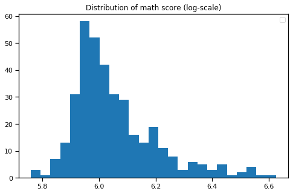

```python
plt.figure(figsize = (8,5))
plt.hist(np.log(df.math), bins = 25)
plt.title("Distribution of math score (log-scale)")
plt.legend()
plt.show()
```

### Train/Test Split

```python
X = df.drop('math', axis=1)
Y = np.log(df.math)
```

```python
indices = range(df.shape[0])
i_boroughs= []
len_iboroughs = []
```

```python
for s in boroughs:
    i_borough = np.where(df.Borough == s)[0]
    len_iboroughs.append(len(i_borough))
    i_boroughs.append(i_borough)
```

```python
min_len = min(len_iboroughs)
train_size = round(min_len*0.8)
```

```python
train_idx = []
test_idx = []
```

```python
for s in i_boroughs:
    np.random.shuffle(s)
    train_idx = np.concatenate((train_idx, s[:train_size]), axis=None)
    test_idx = np.concatenate((test_idx, s[train_size:]), axis=None)
```

```python
df.shape[0]
```

```
365
```

```python
len(train_idx)
```

```
220
```

```python
len(test_idx)
```

```
145
```

```python
X_train = X.iloc[train_idx,:]
X_test = X.iloc[test_idx,:].reset_index()
Y_train = Y.iloc[train_idx]
Y_test = Y.iloc[test_idx]
```

## Pooled model

```python
pooled_code = """
data {
    int<lower=0>  N;
    int<lower=0> M;
    vector[N] x;
    vector[M] x_test;
    vector[N] y;
}
parameters {
    vector[2] beta;
    real<lower=0> sigma;
}
model {
    y ~ normal(beta[1] + beta[2]*x, sigma);
}
generated quantities{
    vector[N] log_lik;
    vector[M] y_pred_test;
    for (i in 1:M)
     y_pred_test[i] = normal_rng(beta[1] + beta[2]*x_test[i], sigma);
    for (i in 1:N)
     log_lik[i] = normal_lpdf(y[i]| beta[1] + beta[2]*x[i], sigma);
}

"""
```

```python
import pystan
import pystan.diagnostics

pool_data = {
    'N': Y_train.shape[0],
    'M': Y_test.shape[0],
    'x': X_train.loc[:,'Enrollment'],
    'x_test': X_test.loc[:,'Enrollment'],
    'y': Y_train,
}
```

```python
pooled_fit = pystan.stan(model_code=pooled_code, data = pool_data, iter = 1000, chains = 2)
```

```
INFO:pystan:COMPILING THE C++ CODE FOR MODEL anon_model_174aac4ec68a4e0adc2676445f7b9556 NOW.
WARNING:pystan:515 of 1000 iterations saturated the maximum tree depth of 10 (51.5%)
WARNING:pystan:Run again with max_treedepth larger than 10 to avoid saturation
```

```python
print("Rhat check : ",pystan.diagnostics.check_rhat(pooled_fit))
print("N_eff check : ",pystan.diagnostics.check_n_eff(pooled_fit))
print("Divergence check: ", pystan.diagnostics.check_div(pooled_fit))
```

```
Rhat check :  True
N_eff check :  True
Divergence check:  True
```

```
psisloo:  114.00256898917883
p_eff:  4.596387507724671
```

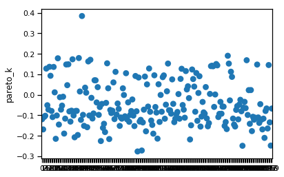

```python
pooled_sample = pooled_fit.extract(permuted=True)

loglik = (pooled_sample["log_lik"])
psisloo = stanity.psisloo(loglik)
print("psisloo: ",psisloo.elpd)
psisloo.plot()
lppd_pooled = 0
for i in range (Y_train.shape[0]):
    lppd_pooled = lppd_pooled + np.log(np.mean(np.exp(loglik[:,i])))

peff_pooled = np.sum(lppd_pooled) - psisloo.elpd
print("p_eff: ", peff_pooled)
```

```python
psisloo.print_summary()
```

```
greater than 0.5    0.0
greater than 1      0.0
dtype: float64
```

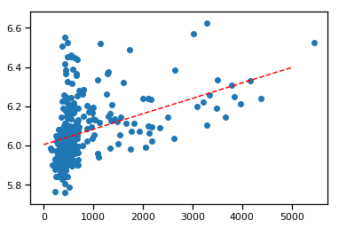

```python
b0, m0 = pooled_sample['beta'].T.mean(1)
plt.scatter(df.Enrollment, np.log(df.math))
xvals = np.linspace(0,5000)
plt.plot(xvals, m0*xvals+b0, 'r--')
plt.show()
```

```
0.095
```

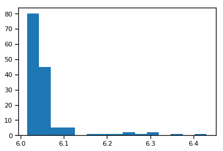

```python
#Comparing y_pred with y_test
y_pred = np.mean(pooled_sample["y_pred_test"], axis=0)
plt.hist(y_pred, bins = 15)
round(MAE(Y_test, y_pred),3)
```

```python
round(MSE(Y_test, y_pred),3)
```

```
0.014
```

## Separate model

```python
separate_code = """
data{
    int<lower=0> N;
    int<lower=1, upper=5> boroughs[N]; #borough indicator
    vector[N] x;
    vector[N] y;
}
parameters {
    vector[4] alpha;
    real beta; #only 1 beta, not a vector
    real<lower=0> sigma;
}
transformed parameters {
    vector[N] mu;
    for (i in 1:N)
        mu[i] <- beta* x[i] + alpha[boroughs[i]];
}
model {
    y ~ normal(mu, sigma);
}
generated quantities{
    vector[N] log_lik;
    for (i in 1:N)
     log_lik[i] = normal_lpdf(y[i]| mu[i], sigma);
}
"""
```

```python
separate_data = {'N': X_train.shape[0],
                 'boroughs': X_train.Borough,
                 'x': X_train.loc[:,'Enrollment'],
                 'y': Y_train }
```

```python
separate_fit = pystan.stan(model_code = separate_code, data = separate_data, iter = 1000, chains = 2)
separate_sample = separate_fit.extract(permuted=True)
```

```
INFO:pystan:COMPILING THE C++ CODE FOR MODEL anon_model_aae52bba719395c276d180e52079c523 NOW.
WARNING:pystan:946 of 1000 iterations saturated the maximum tree depth of 10 (94.6%)
WARNING:pystan:Run again with max_treedepth larger than 10 to avoid saturation
```

```python
print("Rhat check : ",pystan.diagnostics.check_rhat(separate_fit))
print("N_eff check : ",pystan.diagnostics.check_n_eff(separate_fit))
print("Divergence check: ", pystan.diagnostics.check_div(separate_fit))
```

```
Rhat check :  True
N_eff check :  True
Divergence check:  True
```

```python
alpha = np.mean(separate_fit['alpha'], axis=0)
beta = np.mean(separate_fit['beta'])
```

```
psisloo:  126.17399572808584
p_eff:  6.810815331221775
```

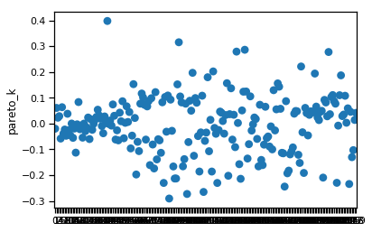

```python
loglik = (separate_sample["log_lik"])
psisloo = stanity.psisloo(loglik)
print("psisloo: ",psisloo.elpd)
psisloo.plot()
lppd_pooled = 0
for i in range (Y_train.shape[0]):
    lppd_pooled = lppd_pooled + np.log(np.mean(np.exp(loglik[:,i])))

peff_pooled = np.sum(lppd_pooled) - psisloo.elpd
print("p_eff: ", peff_pooled)
```

```python
psisloo.print_summary()
```

```
greater than 0.5    0.0
greater than 1      0.0
dtype: float64
```

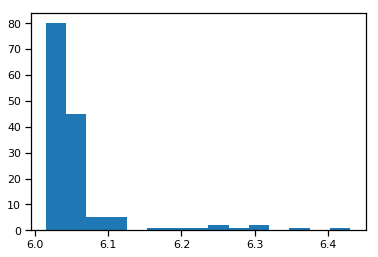

```python
Y_pred = []
for i in range(X_test.shape[0]):
    borough = X_test.loc[i, 'Borough']
    Y_pred.append(alpha[borough-1] + beta*X_test.loc[i, 'Enrollment'])

plt.hist(y_pred, bins = 15)
```

```python
MAE(Y_pred, Y_test)
```

```
0.08616224390564506
```

```python
MSE(Y_pred, Y_test)
```

```
0.013264286057176913
```

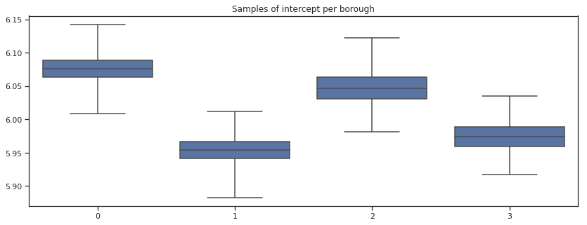

```python
import seaborn as sns
sns.set(style="ticks")

a_sample = pd.DataFrame(separate_fit['alpha'])
plt.figure(figsize=(14, 5))
sns.boxplot(data=a_sample, whis=np.inf, color="b")
plt.title("Samples of intercept per borough")
plt.show()
```

# Varying intercept and slope model

```python
varying_intercept_slope = """
data {
  int<lower=0> N;
  int<lower=0> J;
  vector[N] y;
  vector[N] x;
  int boroughs[N];
}
parameters {
  real<lower=0> sigma;
  real<lower=0> sigma_a;
  real<lower=0> sigma_b;
  vector[J] alpha;
  vector[J] beta;
  real mu_a;
  real mu_b;
}
transformed parameters {
    vector[N] mu;
    for (i in 1:N)
        mu[i] <- alpha[boroughs[i]] + beta[boroughs[i]]*x[i];
}
model {
  mu_a ~ normal(0, 1);
  mu_b ~ normal(0, 1);

  alpha ~ normal(mu_a, sigma_a);
  beta ~ normal(mu_b, sigma_b);
  y ~ normal(mu, sigma);
}

generated quantities{
    vector[N] log_lik;
    for (i in 1:N)
     log_lik[i] = normal_lpdf(y[i]| mu[i], sigma);
}

"""
```

```python
varying_intercept_slope_data = {'N': df.shape[0],
                          'J': 4,
                          'boroughs': df.loc[:, 'Borough'],
                          'x': df.loc[:,'Enrollment'],
                          'y': np.log(df.math)}

varying_intercept_slope_fit = pystan.stan(model_code=varying_intercept_slope,
                                          data=varying_intercept_slope_data,
                                          iter=1000, chains=2)
varying_intercept_slope_sample = varying_intercept_slope_fit.extract(permuted=True)
```

```
INFO:pystan:COMPILING THE C++ CODE FOR MODEL anon_model_989c483a074c9067ebf9bb4c197bcf99 NOW.
WARNING:pystan:Rhat for parameter sigma_b is 1.2682052088714062!
WARNING:pystan:Rhat for parameter mu_a is 1.1595623921760068!
WARNING:pystan:Rhat above 1.1 or below 0.9 indicates that the chains very likely have not mixed
WARNING:pystan:249 of 1000 iterations ended with a divergence (24.9%).
WARNING:pystan:Try running with adapt_delta larger than 0.8 to remove the divergences.
WARNING:pystan:722 of 1000 iterations saturated the maximum tree depth of 10 (72.2%)
WARNING:pystan:Run again with max_treedepth larger than 10 to avoid saturation
```

```python
df.loc[:, 'Borough'].unique()
```

```
array([1, 2, 3, 4])
```

```python
print("Rhat check : ",pystan.diagnostics.check_rhat(varying_intercept_slope_fit))
print("N_eff check : ",pystan.diagnostics.check_n_eff(varying_intercept_slope_fit))
print("Divergence check: ", pystan.diagnostics.check_div(varying_intercept_slope_fit))
```

```
WARNING:pystan:Rhat for parameter sigma_b is 1.2682052088714062!
WARNING:pystan:Rhat for parameter mu_a is 1.1595623921760068!
WARNING:pystan:Rhat above 1.1 or below 0.9 indicates that the chains very likely have not mixed
```

```
Rhat check :  False
```

```
WARNING:pystan:249 of 1000 iterations ended with a divergence (24.9%).
WARNING:pystan:Try running with adapt_delta larger than 0.8 to remove the divergences.
```

```
N_eff check :  True
Divergence check:  False
```

```python
varying_intercept_slope_sample
```

[output not shown]

[output cut: 1344 more lines]

[output not shown]

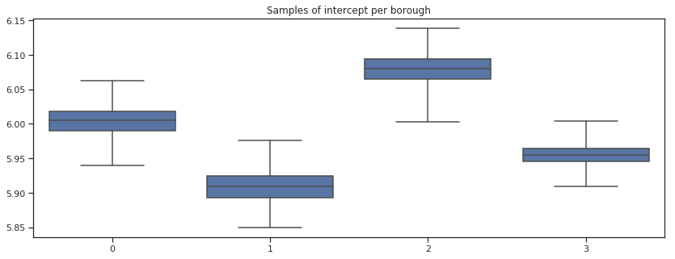

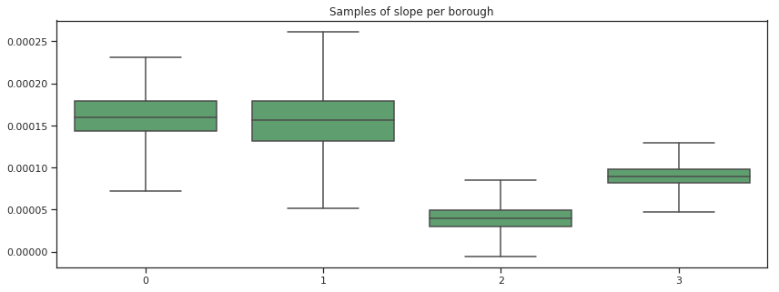

```python
sns.set(style="ticks")

a_sample = pd.DataFrame(varying_intercept_slope_sample['alpha'])
plt.figure(figsize=(14, 5))
sns.boxplot(data=a_sample, whis=np.inf, color="b")
plt.title("Samples of intercept per borough")
plt.show()

b_sample = pd.DataFrame(varying_intercept_slope_sample['beta'])
plt.figure(figsize=(14, 5))
sns.boxplot(data=b_sample, whis=np.inf, color = 'g')
plt.title("Samples of slope per borough")
plt.show()
```

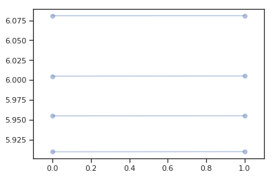

```python
xvals = np.arange(2)
b = varying_intercept_slope_fit['alpha'].mean(axis=0)
m = varying_intercept_slope_fit['beta'].mean(axis=0)
for bi,mi in zip(b,m):
    plt.plot(xvals, mi*xvals + bi, 'bo-', alpha=0.4)
plt.xlim(-0.1, 1.1);
```

```
psisloo:  241.14065591069652
p_eff:  -90.52821374353678
```

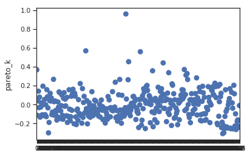

```python
loglik = (varying_intercept_slope_sample["log_lik"])
psisloo = stanity.psisloo(loglik)
print("psisloo: ",psisloo.elpd)
psisloo.plot()
lppd_pooled = 0
for i in range (Y_train.shape[0]):
    lppd_pooled = lppd_pooled + np.log(np.mean(np.exp(loglik[:,i])))

peff_pooled = np.sum(lppd_pooled) - psisloo.elpd
print("p_eff: ", peff_pooled)
```

```python
psisloo.print_summary()
```

```
greater than 0.5    0.008219
greater than 1      0.000000
dtype: float64
```

## Hierarchical model

```python
hierarchical_code = """
data {
    int<lower=1> N;
    int<lower=1> K;
    matrix[N, K] y;
}
parameters {
    real mu0;
    real<lower=0> sigma0;
    vector[K] mu;
    real<lower=0> sigma;
}
model {
    for (j in 1:K){
        mu[j] ~ normal(mu0, sigma0);
        y[:,j] ~ normal(mu[j], sigma);
     }
}
generated quantities {
    real mupred;
    mupred <- normal_rng(mu0, sigma0);
}
"""
```

```python
data = []
for s in i_boroughs:
    np.random.shuffle(s)
    s = s[:min_len]
    data.append(Y.iloc[s])
```

```python
data = np.array(data)
```

```python
y_test = np.log(test_df.math)

data_hierarchical = {
    'N': data.shape[0],
    'K': data.shape[1],
    'y': data
}

fit_hierarchical = pystan.stan(model_code = hierarchical_code, data = data_hierarchical, iter=2000, chains=2)
mu_pred = np.mean(fit_hierarchical['mupred'])
sigma_pred = np.mean(fit_hierarchical['sigma'])
mu_ytest = np.mean(y_test)
sigma_ytest = np.std(y_test)
y_norm = (y_test - mu_ytest)/sigma_ytest
y_pred = (y_norm * sigma_pred) + mu_pred
```

```
INFO:pystan:COMPILING THE C++ CODE FOR MODEL anon_model_bb063ad4e6e043a948b6541ceedcd53e NOW.
WARNING:pystan:47 of 2000 iterations ended with a divergence (2.35%).
WARNING:pystan:Try running with adapt_delta larger than 0.8 to remove the divergences.
WARNING:pystan:Chain 1: E-BFMI = 0.07194037555424869
WARNING:pystan:Chain 2: E-BFMI = 0.06633207100085611
WARNING:pystan:E-BFMI below 0.2 indicates you may need to reparameterize your model
```

```python
print("Rhat check : ",pystan.diagnostics.check_rhat(fit_hierarchical))
print("N_eff check : ",pystan.diagnostics.check_n_eff(fit_hierarchical))
print("Divergence check: ", pystan.diagnostics.check_div(fit_hierarchical))
```

```
Rhat check :  True
```

```
WARNING:pystan:47 of 2000 iterations ended with a divergence (2.35%).
WARNING:pystan:Try running with adapt_delta larger than 0.8 to remove the divergences.
```

```
N_eff check :  True
Divergence check:  False
```

```python
round(MAE(y_test, y_pred),3)
```

```
0.111
```

```python
round(MSE(y_test, y_pred),3)
```

```
0.013
```